# QWizard Class

The QWizard class provides a framework for wizards. More...

| Header: | `#include <QWizard>` |
| --- | --- |
| CMake: | `find_package(Qt6 REQUIRED COMPONENTS Widgets)` `target_link_libraries(mytarget PRIVATE Qt6::Widgets)` |
| qmake: | `QT += widgets` |
| Inherits: | QDialog |

- [List of all members, including inherited members](https://doc.qt.io/qt-6.9/qwizard-members.html)

## Public Types

| enum | **WizardButton** { BackButton, NextButton, CommitButton, FinishButton, CancelButton, …, Stretch } |
| --- | --- |
| enum | **WizardOption** { IndependentPages, IgnoreSubTitles, ExtendedWatermarkPixmap, NoDefaultButton, NoBackButtonOnStartPage, …, NoCancelButtonOnLastPage } |
| flags | **WizardOptions** |
| enum | **WizardPixmap** { WatermarkPixmap, LogoPixmap, BannerPixmap, BackgroundPixmap } |
| enum | **WizardStyle** { ClassicStyle, ModernStyle, MacStyle, AeroStyle } |

## Properties

- **currentId** : int
- **options** : WizardOptions
- **startId** : int
- **subTitleFormat** : Qt::TextFormat
- **titleFormat** : Qt::TextFormat
- **wizardStyle** : WizardStyle

## Public Functions

|  | **QWizard**(QWidget **parent* = nullptr, Qt::WindowFlags *flags* = Qt::WindowFlags()) |
| --- | --- |
| virtual | **~QWizard**() |
| int | **addPage**(QWizardPage **page*) |
| QAbstractButton * | **button**(QWizard::WizardButton *which*) const |
| QString | **buttonText**(QWizard::WizardButton *which*) const |
| int | **currentId**() const |
| QWizardPage * | **currentPage**() const |
| QVariant | **field**(const QString &*name*) const |
| bool | **hasVisitedPage**(int *id*) const |
| virtual int | **nextId**() const |
| QWizard::WizardOptions | **options**() const |
| QWizardPage * | **page**(int *id*) const |
| QList<int> | **pageIds**() const |
| QPixmap | **pixmap**(QWizard::WizardPixmap *which*) const |
| void | **removePage**(int *id*) |
| void | **setButton**(QWizard::WizardButton *which*, QAbstractButton **button*) |
| void | **setButtonLayout**(const QList<QWizard::WizardButton> &*layout*) |
| void | **setButtonText**(QWizard::WizardButton *which*, const QString &*text*) |
| void | **setDefaultProperty**(const char **className*, const char **property*, const char **changedSignal*) |
| void | **setField**(const QString &*name*, const QVariant &*value*) |
| void | **setOption**(QWizard::WizardOption *option*, bool *on* = true) |
| void | **setOptions**(QWizard::WizardOptions *options*) |
| void | **setPage**(int *id*, QWizardPage **page*) |
| void | **setPixmap**(QWizard::WizardPixmap *which*, const QPixmap &*pixmap*) |
| void | **setSideWidget**(QWidget **widget*) |
| void | **setStartId**(int *id*) |
| void | **setSubTitleFormat**(Qt::TextFormat *format*) |
| void | **setTitleFormat**(Qt::TextFormat *format*) |
| void | **setWizardStyle**(QWizard::WizardStyle *style*) |
| QWidget * | **sideWidget**() const |
| int | **startId**() const |
| Qt::TextFormat | **subTitleFormat**() const |
| bool | **testOption**(QWizard::WizardOption *option*) const |
| Qt::TextFormat | **titleFormat**() const |
| virtual bool | **validateCurrentPage**() |
| QList<int> | **visitedIds**() const |
| QWizard::WizardStyle | **wizardStyle**() const |

## Reimplemented Public Functions

| virtual void | **setVisible**(bool *visible*) override |
| --- | --- |
| virtual QSize | **sizeHint**() const override |

## Public Slots

| void | **back**() |
| --- | --- |
| void | **next**() |
| void | **restart**() |
| void | **setCurrentId**(int *id*) |

## Signals

| void | **currentIdChanged**(int *id*) |
| --- | --- |
| void | **customButtonClicked**(int *which*) |
| void | **helpRequested**() |
| void | **pageAdded**(int *id*) |
| void | **pageRemoved**(int *id*) |

## Protected Functions

| virtual void | **cleanupPage**(int *id*) |
| --- | --- |
| virtual void | **initializePage**(int *id*) |

## Reimplemented Protected Functions

| virtual void | **done**(int *result*) override |
| --- | --- |
| virtual bool | **event**(QEvent **event*) override |
| virtual bool | **nativeEvent**(const QByteArray &*eventType*, void **message*, qintptr **result*) override |
| virtual void | **paintEvent**(QPaintEvent **event*) override |
| virtual void | **resizeEvent**(QResizeEvent **event*) override |

## Detailed Description

A wizard (also called an assistant on macOS) is a special type of input dialog that consists of a sequence of pages. A wizard's purpose is to guide the user through a process step by step. Wizards are useful for complex or infrequent tasks that users may find difficult to learn.

QWizard inherits QDialog and represents a wizard. Each page is a QWizardPage (a QWidget subclass). To create your own wizards, you can use these classes directly, or you can subclass them for more control.

### A Trivial Example

The following example illustrates how to create wizard pages and add them to a wizard. For more advanced examples, see the [License Wizard](https://doc.qt.io/qt-6.9/qtwidgets-dialogs-licensewizard-example.html).

```
QWizardPage *createIntroPage()
{
    QWizardPage *page = new QWizardPage;
    page->setTitle("Introduction");

    QLabel *label = new QLabel("This wizard will help you register your copy "
                               "of Super Product Two.");
    label->setWordWrap(true);

    QVBoxLayout *layout = new QVBoxLayout;
    layout->addWidget(label);
    page->setLayout(layout);

    return page;
}

QWizardPage *createRegistrationPage()
{
    ...
}

QWizardPage *createConclusionPage()
{
    ...
}

int main(int argc, char *argv[])
{
    QApplication app(argc, argv);

#ifndef QT_NO_TRANSLATION
    QString translatorFileName = QLatin1String("qtbase_");
    translatorFileName += QLocale::system().name();
    QTranslator *translator = new QTranslator(&app);
    if (translator->load(translatorFileName, QLibraryInfo::path(QLibraryInfo::TranslationsPath)))
        app.installTranslator(translator);
#endif

    QWizard wizard;
    wizard.addPage(createIntroPage());
    wizard.addPage(createRegistrationPage());
    wizard.addPage(createConclusionPage());

    wizard.setWindowTitle("Trivial Wizard");
    wizard.show();

    return app.exec();
}
```

### Wizard Look and Feel

QWizard supports four wizard looks:

- ClassicStyle
- ModernStyle
- MacStyle
- AeroStyle

You can explicitly set the look to use using setWizardStyle() (e.g., if you want the same look on all platforms).

ClassicStyle

ModernStyle

MacStyle

AeroStyle

[figure not shown]

[figure not shown]

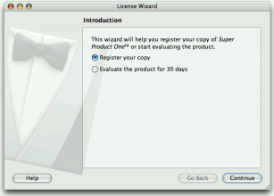

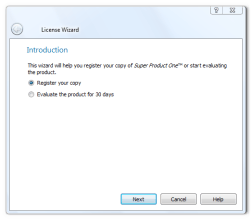

[figure not shown]

[figure not shown]

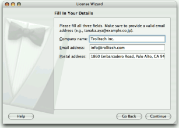

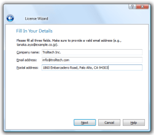

Note: AeroStyle has effect only on a Windows Vista system with alpha compositing enabled. ModernStyle is used as a fallback when this condition is not met.

In addition to the wizard style, there are several options that control the look and feel of the wizard. These can be set using setOption() or setOptions(). For example, HaveHelpButton makes QWizard show a **Help** button along with the other wizard buttons.

You can even change the order of the wizard buttons to any arbitrary order using setButtonLayout(), and you can add up to three custom buttons (e.g., a **Print** button) to the button row. This is achieved by calling setButton() or setButtonText() with CustomButton1, CustomButton2, or CustomButton3 to set up the button, and by enabling the HaveCustomButton1, HaveCustomButton2, or HaveCustomButton3 options. Whenever the user clicks a custom button, customButtonClicked() is emitted. For example:

```
        wizard()->setButtonText(QWizard::CustomButton1, tr("&Print"));
        wizard()->setOption(QWizard::HaveCustomButton1, true);
        connect(wizard(), &QWizard::customButtonClicked,
                this, &ConclusionPage::printButtonClicked);
```

### Elements of a Wizard Page

Wizards consist of a sequence of QWizardPages. At any time, only one page is shown. A page has the following attributes:

- A title.
- A subTitle.
- A set of pixmaps, which may or may not be honored, depending on the wizard's style:
  - WatermarkPixmap (used by ClassicStyle and ModernStyle)
  - BannerPixmap (used by ModernStyle)
  - LogoPixmap (used by ClassicStyle and ModernStyle)
  - BackgroundPixmap (used by MacStyle)

The diagram belows shows how QWizard renders these attributes, assuming they are all present and ModernStyle is used:

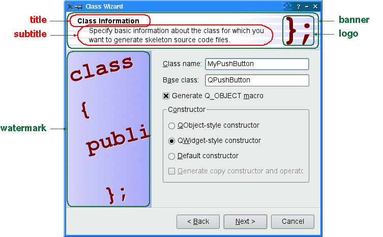

When a subTitle is set, QWizard displays it in a header, in which case it also uses the BannerPixmap and the LogoPixmap to decorate the header. The WatermarkPixmap is displayed on the left side, below the header. At the bottom, there is a row of buttons allowing the user to navigate through the pages.

The page itself (the QWizardPage widget) occupies the area between the header, the watermark, and the button row. Typically, the page is a QWizardPage on which a QGridLayout is installed, with standard child widgets (QLabels, QLineEdits, etc.).

If the wizard's style is MacStyle, the page looks radically different:

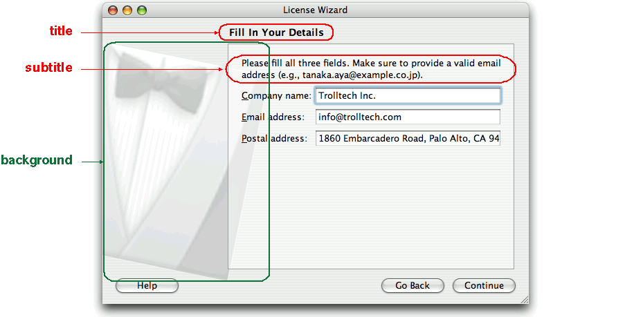

The watermark, banner, and logo pixmaps are ignored by the MacStyle. If the BackgroundPixmap is set, it is used as the background for the wizard; otherwise, a default "assistant" image is used.

The title and subtitle are set by calling QWizardPage::setTitle() and QWizardPage::setSubTitle() on the individual pages. They may be plain text or HTML (see titleFormat and subTitleFormat). The pixmaps can be set globally for the entire wizard using setPixmap(), or on a per-page basis using QWizardPage::setPixmap().

### Registering and Using Fields

In many wizards, the contents of a page may affect the default values of the fields of a later page. To make it easy to communicate between pages, QWizard supports a "field" mechanism that allows you to register a field (e.g., a QLineEdit) on a page and to access its value from any page. It is also possible to specify mandatory fields (i.e., fields that must be filled before the user can advance to the next page).

To register a field, call QWizardPage::registerField() field. For example:

```
    registerField("evaluate.name*", nameLineEdit);
    registerField("evaluate.email*", emailLineEdit);
```

The fields of any page are accessible from any other page. For example:

```
void ConclusionPage::initializePage()
{
    QString licenseText;

    if (wizard()->hasVisitedPage(LicenseWizard::Page_Evaluate)) {
        licenseText = tr("<u>Evaluation License Agreement:</u> "
                         "You can use this software for 30 days and make one "
                         "backup, but you are not allowed to distribute it.");
    } else if (wizard()->hasVisitedPage(LicenseWizard::Page_Details)) {
        const QString emailAddress = field("details.email").toString();
        licenseText = tr("<u>First-Time License Agreement:</u> "
                         "You can use this software subject to the license "
                         "you will receive by email sent to %1.").arg(emailAddress);
    } else {
        licenseText = tr("<u>Upgrade License Agreement:</u> "
                         "This software is licensed under the terms of your "
                         "current license.");
    }
    bottomLabel->setText(licenseText);
}
```

Here, we call QWizardPage::field() to access the contents of the `details.email` field (which was defined in the `DetailsPage`) and use it to initialize the `ConclusionPage`. The field's contents is returned as a QVariant.

When we create a field using QWizardPage::registerField(), we pass a unique field name and a widget. We can also provide a Qt property name and a "changed" signal (a signal that is emitted when the property changes) as third and fourth arguments; however, this is not necessary for the most common Qt widgets, such as QLineEdit, QCheckBox, and QComboBox, because QWizard knows which properties to look for.

If an asterisk (`*`) is appended to the name when the property is registered, the field is a *mandatory field*. When a page has mandatory fields, the **Next** and/or **Finish** buttons are enabled only when all mandatory fields are filled.

To consider a field "filled", QWizard simply checks that the field's current value doesn't equal the original value (the value it had when initializePage() was called). For QLineEdit and QAbstractSpinBox subclasses, QWizard also checks that hasAcceptableInput() returns true, to honor any validator or mask.

QWizard's mandatory field mechanism is provided for convenience. A more powerful (but also more cumbersome) alternative is to reimplement QWizardPage::isComplete() and to emit the QWizardPage::completeChanged() signal whenever the page becomes complete or incomplete.

The enabled/disabled state of the **Next** and/or **Finish** buttons is one way to perform validation on the user input. Another way is to reimplement validateCurrentPage() (or QWizardPage::validatePage()) to perform some last-minute validation (and show an error message if the user has entered incomplete or invalid information). If the function returns `true`, the next page is shown (or the wizard finishes); otherwise, the current page stays up.

### Creating Linear Wizards

Most wizards have a linear structure, with page 1 followed by page 2 and so on until the last page. The [Trivial Wizard](https://doc.qt.io/qt-6.9/qtwidgets-dialogs-trivialwizard-example.html) example is such a wizard. With QWizard, linear wizards are created by instantiating the QWizardPages and inserting them using addPage(). By default, the pages are shown in the order in which they were added. For example:

```
    QWizard wizard;
    wizard.addPage(createIntroPage());
    wizard.addPage(createRegistrationPage());
    wizard.addPage(createConclusionPage());
```

When a page is about to be shown, QWizard calls initializePage() (which in turn calls QWizardPage::initializePage()) to fill the page with default values. By default, this function does nothing, but it can be reimplemented to initialize the page's contents based on other pages' fields (see the example above).

If the user presses **Back**, cleanupPage() is called (which in turn calls QWizardPage::cleanupPage()). The default implementation resets the page's fields to their original values (the values they had before initializePage() was called). If you want the **Back** button to be non-destructive and keep the values entered by the user, simply enable the IndependentPages option.

### Creating Non-Linear Wizards

Some wizards are more complex in that they allow different traversal paths based on the information provided by the user. The [License Wizard](https://doc.qt.io/qt-6.9/qtwidgets-dialogs-licensewizard-example.html) example illustrates this. It provides several wizard pages; depending on which options are selected, the user can reach different pages.

[figure not shown]

In complex wizards, pages are identified by IDs. These IDs are typically defined using an enum. For example:

```
class LicenseWizard : public QWizard
{
    ...
    enum { Page_Intro, Page_Evaluate, Page_Register, Page_Details,
           Page_Conclusion };
    ...
};
```

The pages are inserted using setPage(), which takes an ID and an instance of QWizardPage (or of a subclass):

```
LicenseWizard::LicenseWizard(QWidget *parent)
    : QWizard(parent)
{
    setPage(Page_Intro, new IntroPage);
    setPage(Page_Evaluate, new EvaluatePage);
    setPage(Page_Register, new RegisterPage);
    setPage(Page_Details, new DetailsPage);
    setPage(Page_Conclusion, new ConclusionPage);
    ...
}
```

By default, the pages are shown in increasing ID order. To provide a dynamic order that depends on the options chosen by the user, we must reimplement QWizardPage::nextId(). For example:

```
int IntroPage::nextId() const
{
    if (evaluateRadioButton->isChecked()) {
        return LicenseWizard::Page_Evaluate;
    } else {
        return LicenseWizard::Page_Register;
    }
}

int EvaluatePage::nextId() const
{
    return LicenseWizard::Page_Conclusion;
}

int RegisterPage::nextId() const
{
    if (upgradeKeyLineEdit->text().isEmpty()) {
        return LicenseWizard::Page_Details;
    } else {
        return LicenseWizard::Page_Conclusion;
    }
}

int DetailsPage::nextId() const
{
    return LicenseWizard::Page_Conclusion;
}

int ConclusionPage::nextId() const
{
    return -1;
}
```

It would also be possible to put all the logic in one place, in a QWizard::nextId() reimplementation. For example:

```
int LicenseWizard::nextId() const
{
    switch (currentId()) {
    case Page_Intro:
        if (field("intro.evaluate").toBool()) {
            return Page_Evaluate;
        } else {
            return Page_Register;
        }
    case Page_Evaluate:
        return Page_Conclusion;
    case Page_Register:
        if (field("register.upgradeKey").toString().isEmpty()) {
            return Page_Details;
        } else {
            return Page_Conclusion;
        }
    case Page_Details:
        return Page_Conclusion;
    case Page_Conclusion:
    default:
        return -1;
    }
}
```

To start at another page than the page with the lowest ID, call setStartId().

To test whether a page has been visited or not, call hasVisitedPage(). For example:

```
void ConclusionPage::initializePage()
{
    QString licenseText;

    if (wizard()->hasVisitedPage(LicenseWizard::Page_Evaluate)) {
        licenseText = tr("<u>Evaluation License Agreement:</u> "
                         "You can use this software for 30 days and make one "
                         "backup, but you are not allowed to distribute it.");
    } else if (wizard()->hasVisitedPage(LicenseWizard::Page_Details)) {
        const QString emailAddress = field("details.email").toString();
        licenseText = tr("<u>First-Time License Agreement:</u> "
                         "You can use this software subject to the license "
                         "you will receive by email sent to %1.").arg(emailAddress);
    } else {
        licenseText = tr("<u>Upgrade License Agreement:</u> "
                         "This software is licensed under the terms of your "
                         "current license.");
    }
    bottomLabel->setText(licenseText);
}
```

**See also** QWizardPage, [Trivial Wizard Example](https://doc.qt.io/qt-6.9/qtwidgets-dialogs-trivialwizard-example.html), and [License Wizard Example](https://doc.qt.io/qt-6.9/qtwidgets-dialogs-licensewizard-example.html).

## Member Type Documentation

### enum QWizard::WizardButton

This enum specifies the buttons in a wizard.

| Constant | Value | Description |
| --- | --- | --- |
| `QWizard::BackButton` | `0` | The **Back** button (**Go Back** on macOS) |
| `QWizard::NextButton` | `1` | The **Next** button (**Continue** on macOS) |
| `QWizard::CommitButton` | `2` | The **Commit** button |
| `QWizard::FinishButton` | `3` | The **Finish** button (**Done** on macOS) |
| `QWizard::CancelButton` | `4` | The **Cancel** button (see also NoCancelButton) |
| `QWizard::HelpButton` | `5` | The **Help** button (see also HaveHelpButton) |
| `QWizard::CustomButton1` | `6` | The first user-defined button (see also HaveCustomButton1) |
| `QWizard::CustomButton2` | `7` | The second user-defined button (see also HaveCustomButton2) |
| `QWizard::CustomButton3` | `8` | The third user-defined button (see also HaveCustomButton3) |

The following value is only useful when calling setButtonLayout():

| Constant | Value | Description |
| --- | --- | --- |
| `QWizard::Stretch` | `9` | A horizontal stretch in the button layout |

**See also** setButton(), setButtonText(), setButtonLayout(), and customButtonClicked().

### enum QWizard::WizardOption flags QWizard::WizardOptions

This enum specifies various options that affect the look and feel of a wizard.

| Constant | Value | Description |
| --- | --- | --- |
| `QWizard::IndependentPages` | `0x00000001` | The pages are independent of each other (i.e., they don't derive values from each other). |
| `QWizard::IgnoreSubTitles` | `0x00000002` | Don't show any subtitles, even if they are set. |
| `QWizard::ExtendedWatermarkPixmap` | `0x00000004` | Extend any WatermarkPixmap all the way down to the window's edge. |
| `QWizard::NoDefaultButton` | `0x00000008` | Don't make the **Next** or **Finish** button the dialog's default button. |
| `QWizard::NoBackButtonOnStartPage` | `0x00000010` | Don't show the **Back** button on the start page. |
| `QWizard::NoBackButtonOnLastPage` | `0x00000020` | Don't show the **Back** button on the last page. |
| `QWizard::DisabledBackButtonOnLastPage` | `0x00000040` | Disable the **Back** button on the last page. |
| `QWizard::HaveNextButtonOnLastPage` | `0x00000080` | Show the (disabled) **Next** button on the last page. |
| `QWizard::HaveFinishButtonOnEarlyPages` | `0x00000100` | Show the (disabled) **Finish** button on non-final pages. |
| `QWizard::NoCancelButton` | `0x00000200` | Don't show the **Cancel** button. |
| `QWizard::CancelButtonOnLeft` | `0x00000400` | Put the **Cancel** button on the left of **Back** (rather than on the right of **Finish** or **Next**). |
| `QWizard::HaveHelpButton` | `0x00000800` | Show the **Help** button. |
| `QWizard::HelpButtonOnRight` | `0x00001000` | Put the **Help** button on the far right of the button layout (rather than on the far left). |
| `QWizard::HaveCustomButton1` | `0x00002000` | Show the first user-defined button (CustomButton1). |
| `QWizard::HaveCustomButton2` | `0x00004000` | Show the second user-defined button (CustomButton2). |
| `QWizard::HaveCustomButton3` | `0x00008000` | Show the third user-defined button (CustomButton3). |
| `QWizard::NoCancelButtonOnLastPage` | `0x00010000` | Don't show the **Cancel** button on the last page. |

The WizardOptions type is a typedef for QFlags<WizardOption>. It stores an OR combination of WizardOption values.

**See also** setOptions(), setOption(), and testOption().

### enum QWizard::WizardPixmap

This enum specifies the pixmaps that can be associated with a page.

| Constant | Value | Description |
| --- | --- | --- |
| `QWizard::WatermarkPixmap` | `0` | The tall pixmap on the left side of a ClassicStyle or ModernStyle page |
| `QWizard::LogoPixmap` | `1` | The small pixmap on the right side of a ClassicStyle or ModernStyle page header |
| `QWizard::BannerPixmap` | `2` | The pixmap that occupies the background of a ModernStyle page header |
| `QWizard::BackgroundPixmap` | `3` | The pixmap that occupies the background of a MacStyle wizard |

**See also** setPixmap(), QWizardPage::setPixmap(), and Elements of a Wizard Page.

### enum QWizard::WizardStyle

This enum specifies the different looks supported by QWizard.

| Constant | Value | Description |
| --- | --- | --- |
| `QWizard::ClassicStyle` | `0` | Classic Windows look |
| `QWizard::ModernStyle` | `1` | Modern Windows look |
| `QWizard::MacStyle` | `2` | macOS look |
| `QWizard::AeroStyle` | `3` | Windows Aero look |

**See also** setWizardStyle(), WizardOption, and Wizard Look and Feel.

## Property Documentation

### currentId : int

This property holds the ID of the current page

By default, this property has a value of -1, indicating that no page is currently shown.

**Access functions:**

| int | **currentId**() const |
| --- | --- |
| void | **setCurrentId**(int *id*) |

**Notifier signal:**

| void | **currentIdChanged**(int *id*) |
| --- | --- |

**See also** currentPage().

### options : WizardOptions

This property holds the various options that affect the look and feel of the wizard

By default, the following options are set (depending on the platform):

- Windows: HelpButtonOnRight.
- macOS: NoDefaultButton and NoCancelButton.
- X11 and QWS (Qt for Embedded Linux): none.

**Access functions:**

| QWizard::WizardOptions | **options**() const |
| --- | --- |
| void | **setOptions**(QWizard::WizardOptions *options*) |

**See also** wizardStyle.

### startId : int

This property holds the ID of the first page

If this property isn't explicitly set, this property defaults to the lowest page ID in this wizard, or -1 if no page has been inserted yet.

**Access functions:**

| int | **startId**() const |
| --- | --- |
| void | **setStartId**(int *id*) |

**See also** restart() and nextId().

### subTitleFormat : Qt::TextFormat

This property holds the text format used by page subtitles

The default format is Qt::AutoText.

**Access functions:**

| Qt::TextFormat | **subTitleFormat**() const |
| --- | --- |
| void | **setSubTitleFormat**(Qt::TextFormat *format*) |

**See also** QWizardPage::title and titleFormat.

### titleFormat : Qt::TextFormat

This property holds the text format used by page titles

The default format is Qt::AutoText.

**Access functions:**

| Qt::TextFormat | **titleFormat**() const |
| --- | --- |
| void | **setTitleFormat**(Qt::TextFormat *format*) |

**See also** QWizardPage::title and subTitleFormat.

### wizardStyle : WizardStyle

This property holds the look and feel of the wizard

By default, QWizard uses the AeroStyle on a Windows Vista system with alpha compositing enabled, regardless of the current widget style. If this is not the case, the default wizard style depends on the current widget style as follows: MacStyle is the default if the current widget style is QMacStyle, ModernStyle is the default if the current widget style is QWindowsStyle, and ClassicStyle is the default in all other cases.

**Access functions:**

| QWizard::WizardStyle | **wizardStyle**() const |
| --- | --- |
| void | **setWizardStyle**(QWizard::WizardStyle *style*) |

**See also** Wizard Look and Feel and options.

## Member Function Documentation

### `[explicit]` QWizard::QWizard(QWidget **parent* = nullptr, Qt::WindowFlags *flags* = Qt::WindowFlags())

Constructs a wizard with the given *parent* and window *flags*.

**See also** parent() and windowFlags().

### `[virtual noexcept]` QWizard::~QWizard()

Destroys the wizard and its pages, releasing any allocated resources.

### int QWizard::addPage(QWizardPage **page*)

Adds the given *page* to the wizard, and returns the page's ID.

The ID is guaranteed to be larger than any other ID in the QWizard so far.

**See also** setPage(), page(), and pageAdded().

### `[slot]` void QWizard::back()

Goes back to the previous page.

This is equivalent to pressing the **Back** button.

**See also** next(), accept(), reject(), and restart().

### QAbstractButton *QWizard::button(QWizard::WizardButton *which*) const

Returns the button corresponding to role *which*.

**See also** setButton() and setButtonText().

### QString QWizard::buttonText(QWizard::WizardButton *which*) const

Returns the text on button *which*.

If a text has ben set using setButtonText(), this text is returned.

By default, the text on buttons depends on the wizardStyle. For example, on macOS, the **Next** button is called **Continue**.

**See also** button(), setButton(), setButtonText(), QWizardPage::buttonText(), and QWizardPage::setButtonText().

### `[virtual protected]` void QWizard::cleanupPage(int *id*)

This virtual function is called by QWizard to clean up page *id* just before the user leaves it by clicking **Back** (unless the QWizard::IndependentPages option is set).

The default implementation calls QWizardPage::cleanupPage() on page(*id*).

**See also** QWizardPage::cleanupPage() and initializePage().

### `[signal]` void QWizard::currentIdChanged(int *id*)

This signal is emitted when the current page changes, with the new current *id*.

**Note:** Notifier signal for property currentId.

**See also** currentId() and currentPage().

### QWizardPage *QWizard::currentPage() const

Returns a pointer to the current page, or `nullptr` if there is no current page (e.g., before the wizard is shown).

This is equivalent to calling page(currentId()).

**See also** page(), currentId(), and restart().

### `[signal]` void QWizard::customButtonClicked(int *which*)

This signal is emitted when the user clicks a custom button. *which* can be CustomButton1, CustomButton2, or CustomButton3.

By default, no custom button is shown. Call setOption() with HaveCustomButton1, HaveCustomButton2, or HaveCustomButton3 to have one, and use setButtonText() or setButton() to configure it.

**See also** helpRequested().

### `[override virtual protected]` void QWizard::done(int *result*)

Reimplements: QDialog::done(int r).

### `[override virtual protected]` bool QWizard::event(QEvent **event*)

Reimplements: QWidget::event(QEvent *event).

### QVariant QWizard::field(const QString &*name*) const

Returns the value of the field called *name*.

This function can be used to access fields on any page of the wizard.

**See also** QWizardPage::registerField(), QWizardPage::field(), and setField().

### bool QWizard::hasVisitedPage(int *id*) const

Returns `true` if the page history contains page *id*; otherwise, returns `false`.

Pressing **Back** marks the current page as "unvisited" again.

**See also** visitedIds().

### `[signal]` void QWizard::helpRequested()

This signal is emitted when the user clicks the **Help** button.

By default, no **Help** button is shown. Call setOption(HaveHelpButton, true) to have one.

Example:

```
LicenseWizard::LicenseWizard(QWidget *parent)
    : QWizard(parent)
{
    ...
    setOption(HaveHelpButton, true);
    connect(this, &QWizard::helpRequested, this, &LicenseWizard::showHelp);
    ...
}

void LicenseWizard::showHelp()
{
    static QString lastHelpMessage;

    QString message;

    switch (currentId()) {
    case Page_Intro:
        message = tr("The decision you make here will affect which page you "
                     "get to see next.");
        break;
    ...
    default:
        message = tr("This help is likely not to be of any help.");
    }

    QMessageBox::information(this, tr("License Wizard Help"), message);

}
```

**See also** customButtonClicked().

### `[virtual protected]` void QWizard::initializePage(int *id*)

This virtual function is called by QWizard to prepare page *id* just before it is shown either as a result of QWizard::restart() being called, or as a result of the user clicking **Next**. (However, if the QWizard::IndependentPages option is set, this function is only called the first time the page is shown.)

By reimplementing this function, you can ensure that the page's fields are properly initialized based on fields from previous pages.

The default implementation calls QWizardPage::initializePage() on page(*id*).

**See also** QWizardPage::initializePage() and cleanupPage().

### `[override virtual protected]` bool QWizard::nativeEvent(const QByteArray &*eventType*, void **message*, qintptr **result*)

Reimplements: QWidget::nativeEvent(const QByteArray &eventType, void *message, qintptr *result).

### `[slot]` void QWizard::next()

Advances to the next page.

This is equivalent to pressing the **Next** or **Commit** button.

**See also** nextId(), back(), accept(), reject(), and restart().

### `[virtual]` int QWizard::nextId() const

This virtual function is called by QWizard to find out which page to show when the user clicks the **Next** button.

The return value is the ID of the next page, or -1 if no page follows.

The default implementation calls QWizardPage::nextId() on the currentPage().

By reimplementing this function, you can specify a dynamic page order.

**See also** QWizardPage::nextId() and currentPage().

### QWizardPage *QWizard::page(int *id*) const

Returns the page with the given *id*, or `nullptr` if there is no such page.

**See also** addPage() and setPage().

### `[signal]` void QWizard::pageAdded(int *id*)

This signal is emitted whenever a page is added to the wizard. The page's *id* is passed as parameter.

**See also** addPage(), setPage(), and startId().

### QList<int> QWizard::pageIds() const

Returns the list of page IDs.

### `[signal]` void QWizard::pageRemoved(int *id*)

This signal is emitted whenever a page is removed from the wizard. The page's *id* is passed as parameter.

**See also** removePage() and startId().

### `[override virtual protected]` void QWizard::paintEvent(QPaintEvent **event*)

Reimplements: QWidget::paintEvent(QPaintEvent *event).

### QPixmap QWizard::pixmap(QWizard::WizardPixmap *which*) const

Returns the pixmap set for role *which*.

By default, the only pixmap that is set is the BackgroundPixmap on macOS.

**See also** setPixmap(), QWizardPage::pixmap(), and Elements of a Wizard Page.

### void QWizard::removePage(int *id*)

Removes the page with the given *id*. cleanupPage() will be called if necessary.

**Note:** Removing a page may influence the value of the startId property.

**See also** addPage(), setPage(), pageRemoved(), and startId().

### `[override virtual protected]` void QWizard::resizeEvent(QResizeEvent **event*)

Reimplements: QDialog::resizeEvent(QResizeEvent *).

### `[slot]` void QWizard::restart()

Restarts the wizard at the start page. This function is called automatically when the wizard is shown.

**See also** startId().

### void QWizard::setButton(QWizard::WizardButton *which*, QAbstractButton **button*)

Sets the button corresponding to role *which* to *button*.

To add extra buttons to the wizard (e.g., a **Print** button), one way is to call setButton() with CustomButton1 to CustomButton3, and make the buttons visible using the HaveCustomButton1 to HaveCustomButton3 options.

**See also** button(), setButtonText(), setButtonLayout(), and options.

### void QWizard::setButtonLayout(const QList<QWizard::WizardButton> &*layout*)

Sets the order in which buttons are displayed to *layout*, where *layout* is a list of WizardButtons.

The default layout depends on the options (e.g., whether HelpButtonOnRight) that are set. You can call this function if you need more control over the buttons' layout than what options already provides.

You can specify horizontal stretches in the layout using Stretch.

Example:

```
MyWizard::MyWizard(QWidget *parent)
    : QWizard(parent)
{
    ...
    QList<QWizard::WizardButton> layout;
    layout << QWizard::Stretch << QWizard::BackButton << QWizard::CancelButton
           << QWizard::NextButton << QWizard::FinishButton;
    setButtonLayout(layout);
    ...
}
```

**See also** setButton(), setButtonText(), and setOptions().

### void QWizard::setButtonText(QWizard::WizardButton *which*, const QString &*text*)

Sets the text on button *which* to be *text*.

By default, the text on buttons depends on the wizardStyle. For example, on macOS, the **Next** button is called **Continue**.

To add extra buttons to the wizard (e.g., a **Print** button), one way is to call setButtonText() with CustomButton1, CustomButton2, or CustomButton3 to set their text, and make the buttons visible using the HaveCustomButton1, HaveCustomButton2, and/or HaveCustomButton3 options.

Button texts may also be set on a per-page basis using QWizardPage::setButtonText().

**See also** buttonText(), setButton(), button(), setButtonLayout(), setOptions(), and QWizardPage::setButtonText().

### `[slot]` void QWizard::setCurrentId(int *id*)

Sets currentId to *id*, without visiting the pages between currentId and *id*.

Returns without page change, if

- wizard holds no pages
- current page is invalid
- given page equals currentId()
- given page is out of range

Note: If pages have been forward skipped and *id* is 0, page visiting history will be deleted

**Note:** Setter function for property currentId.

**See also** currentId().

### void QWizard::setDefaultProperty(const char **className*, const char **property*, const char **changedSignal*)

Sets the default property for *className* to be *property*, and the associated change signal to be *changedSignal*.

The default property is used when an instance of *className* (or of one of its subclasses) is passed to QWizardPage::registerField() and no property is specified.

QWizard knows the most common Qt widgets. For these (or their subclasses), you don't need to specify a *property* or a *changedSignal*. The table below lists these widgets:

| Widget | Property | Change Notification Signal |
| --- | --- | --- |
| QAbstractButton | bool checked | toggled() |
| QAbstractSlider | int value | valueChanged() |
| QComboBox | int currentIndex | currentIndexChanged() |
| QDateTimeEdit | QDateTime dateTime | dateTimeChanged() |
| QLineEdit | QString text | textChanged() |
| QListWidget | int currentRow | currentRowChanged() |
| QSpinBox | int value | valueChanged() |

**See also** QWizardPage::registerField().

### void QWizard::setField(const QString &*name*, const QVariant &*value*)

Sets the value of the field called *name* to *value*.

This function can be used to set fields on any page of the wizard.

**See also** QWizardPage::registerField(), QWizardPage::setField(), and field().

### void QWizard::setOption(QWizard::WizardOption *option*, bool *on* = true)

Sets the given *option* to be enabled if *on* is true; otherwise, clears the given *option*.

**See also** options, testOption(), and setWizardStyle().

### void QWizard::setPage(int *id*, QWizardPage **page*)

Adds the given *page* to the wizard with the given *id*.

**Note:** Adding a page may influence the value of the startId property in case it was not set explicitly.

**See also** addPage(), page(), and pageAdded().

### void QWizard::setPixmap(QWizard::WizardPixmap *which*, const QPixmap &*pixmap*)

Sets the pixmap for role *which* to *pixmap*.

The pixmaps are used by QWizard when displaying a page. Which pixmaps are actually used depend on the wizard style.

Pixmaps can also be set for a specific page using QWizardPage::setPixmap().

**See also** pixmap(), QWizardPage::setPixmap(), and Elements of a Wizard Page.

### void QWizard::setSideWidget(QWidget **widget*)

Sets the given *widget* to be shown on the left side of the wizard. For styles which use the WatermarkPixmap (ClassicStyle and ModernStyle) the side widget is displayed on top of the watermark, for other styles or when the watermark is not provided the side widget is displayed on the left side of the wizard.

Passing `nullptr` shows no side widget.

When the *widget* is not `nullptr` the wizard reparents it.

Any previous side widget is hidden.

You may call setSideWidget() with the same widget at different times.

All widgets set here will be deleted by the wizard when it is destroyed unless you separately reparent the widget after setting some other side widget (or `nullptr`).

By default, no side widget is present.

**See also** sideWidget().

### `[override virtual]` void QWizard::setVisible(bool *visible*)

Reimplements: QDialog::setVisible(bool visible).

### QWidget *QWizard::sideWidget() const

Returns the widget on the left side of the wizard or `nullptr`.

By default, no side widget is present.

**See also** setSideWidget().

### `[override virtual]` QSize QWizard::sizeHint() const

Reimplements: QDialog::sizeHint() const.

### bool QWizard::testOption(QWizard::WizardOption *option*) const

Returns `true` if the given *option* is enabled; otherwise, returns false.

**See also** options, setOption(), and setWizardStyle().

### `[virtual]` bool QWizard::validateCurrentPage()

This virtual function is called by QWizard when the user clicks **Next** or **Finish** to perform some last-minute validation. If it returns `true`, the next page is shown (or the wizard finishes); otherwise, the current page stays up.

The default implementation calls QWizardPage::validatePage() on the currentPage().

When possible, it is usually better style to disable the **Next** or **Finish** button (by specifying mandatory fields or by reimplementing QWizardPage::isComplete()) than to reimplement validateCurrentPage().

**See also** QWizardPage::validatePage() and currentPage().

### QList<int> QWizard::visitedIds() const

Returns the list of IDs of visited pages, in the order in which the pages were visited.

**See also** hasVisitedPage().

© The Qt Company Ltd  
Licensed under the GNU Free Documentation License, Version 1.3.  
https://doc.qt.io/qt-6.9/qwizard.html